# Principal functions in the semipadd2pop package

Karl Gregory

7/21/2021

The function fits a sparse semiparametric regression model to a single data set using user-specified tuning parameter values.

The following code generates a synthetic data set with continuous responses using the `get_semipadd_data` function and uses the `semipadd` function to fit a sparse semiparametric regression model. The `plot_semipadd` function plots the fitted nonparametric effects. The true effects are plotted with dashed lines.

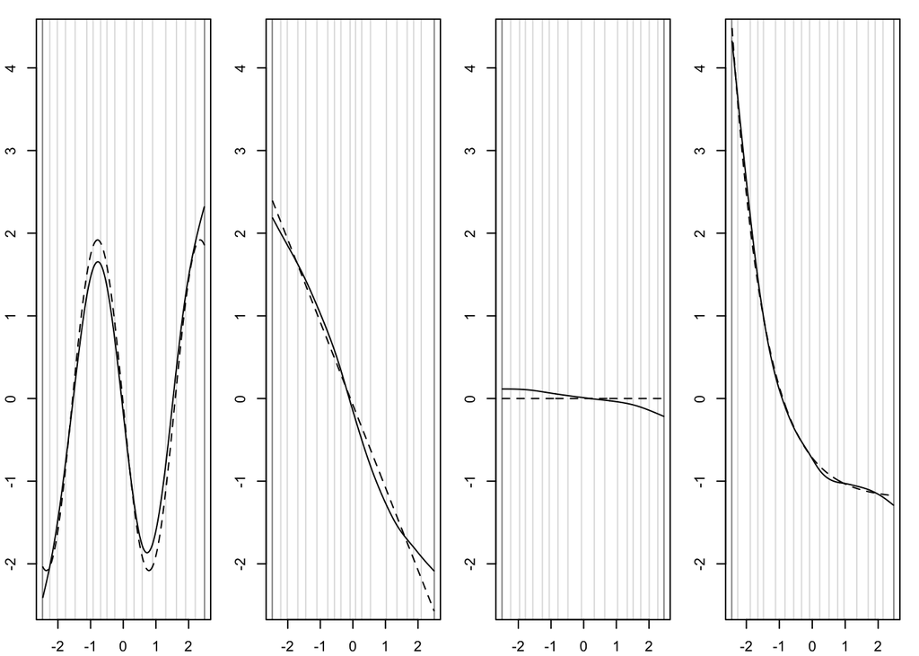

```r
data <- get_semipadd_data(n = 200, response = "continuous")

semipadd.out <- semipadd(Y = data$Y,
                         X = data$X,
                         nonparm = data$nonparm,
                         response = "continuous",
                         w = 1,
                         d = 20,
                         xi = 1,
                         lambda.beta = 1,
                         lambda.f = 1,
                         tol = 1e-3,
                         max.iter = 500)

plot_semipadd(semipadd.out,
              true.functions = list( f = data$f,
                                     X = data$X))
```

The `semipadd_cv_adapt` function fits a sparse semiparametric regression model to a single data set with the tuning parameter governing sparsity chosen via crossvalidation.

The following code generates a synthetic data set with binary responses using the `get_semipadd_data` and uses the `semipadd_cv_adapt` function to fit a sparse semiparametric regression model. The tuning parameter governing sparsity is chosen via crossvalidation. The `plot_semipadd_cv_adapt` function plots the fitted nonparametric effects, showing with transparent curves the fitted effects under candidate tuning parameter values which were not chosen by crossvalidation. The true effects are plotted with dashed lines.

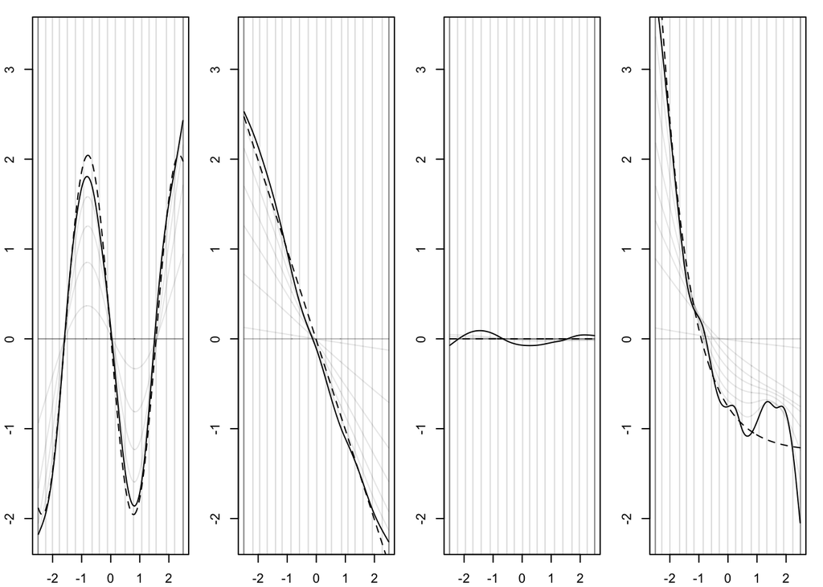

```r
data <- get_semipadd_data(n = 1000, response = "binary")

semipadd_cv_adapt.out <- semipadd_cv_adapt(Y = data$Y,
                                           X = data$X,
                                           nonparm = data$nonparm,
                                           response = "binary",
                                           w = 1,
                                           d = 20,
                                           xi = 1,
                                           n.lambda = 10,
                                           lambda.min.ratio = .001,
                                           lambda.max.ratio = 5,
                                           lambda.beta = 1,
                                           lambda.f = 1,
                                           tol = 1e-3,
                                           maxiter = 1000,
                                           report.prog = FALSE)

plot_semipadd_cv_adapt(semipadd_cv_adapt.out,
                       true.functions  = list( f = data$f,
                                               X = data$X))
```

## Fitting two sparse semiparametric models combining two data sets

The function fits sparse semiparametric regression models to two data set which have come covariates in common using user-specified tuning parameter values.

The following code generates two synthetic data sets with group testing responses using the `get_semipadd2pop_data` function and uses the `semipadd2pop` function to fit sparse semiparametric regression models. The `plot_semipadd2pop` function plots the fitted nonparametric effects in both data sets. The true effects are plotted with dashed lines.

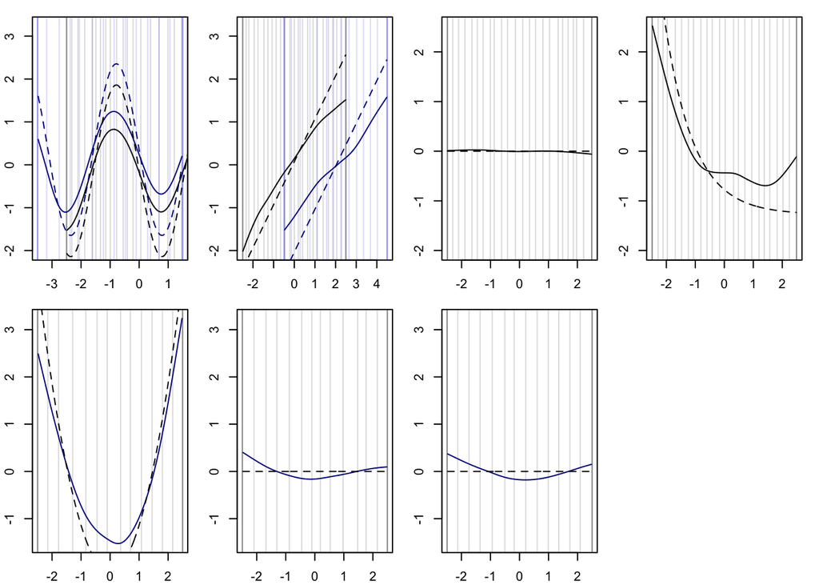

```r
data <- get_semipadd2pop_data(n1 = 500, n2 = 600, response = "gt")

semipadd2pop.out <- semipadd2pop(Y1 = data$Y1,
                                 X1 = data$X1,
                                 nonparm1 = data$nonparm1,
                                 Y2 = data$Y2,
                                 X2 = data$X2,
                                 nonparm2 = data$nonparm2,
                                 response = "gt",
                                 rho1 = 1,
                                 rho2 = 1,
                                 nCom = data$nCom,
                                 d1 = 25,
                                 d2 = 15,
                                 xi = .5,
                                 w1 = 1,
                                 w2 = 1,
                                 w = 1,
                                 lambda.beta = .01,
                                 lambda.f = .01,
                                 eta.beta = .1,
                                 eta.f = .1,
                                 tol = 1e-3,
                                 maxiter = 500)

plot_semipadd2pop(semipadd2pop.out,
                  true.functions = list(f1 = data$f1,
                                        f2 = data$f2,
                                        X1 = data$X1,
                                        X2 = data$X2))
```

The `semipadd2pop_cv_adapt` function fits sparse semiparametric regression models to two data sets with some common covariates with the tuning parameters governing sparsity and penalization towards similar fitting of common effect chosen via crossvalidation.

The following code generates two synthetic data sets with continuous responses using the `get_semipadd2pop_data` and uses the `semipadd2pop_cv_adapt` function to fit a sparse semiparametric regression models for the two data sets. The tuning parameters governing sparsity and penalization towards similarity in the fitted effects of common covariates are chosen via crossvalidation. The `plot_semipadd2pop_cv_adapt` function plots the fitted nonparametric effects in each data set, showing with transparent curves the fitted effects under candidate tuning parameter values which were not chosen by crossvalidation. The true effects are plotted with dashed lines.

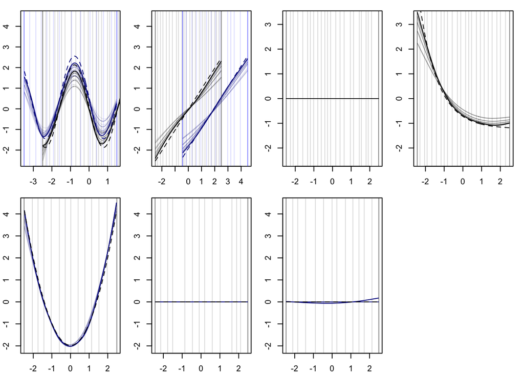

```r
data <- get_semipadd2pop_data(n1 = 300, n2 = 200, response = "continuous")

semipadd2pop_cv_adapt.out <- semipadd2pop_cv_adapt(Y1 = data$Y1,
                                                   X1 = data$X1,
                                                   nonparm1 = data$nonparm1,
                                                   Y2 = data$Y2,
                                                   X2 = data$X2,
                                                   nonparm2 = data$nonparm2,
                                                   response = "continuous",
                                                   rho1 = 2,
                                                   rho2 = 1,
                                                   w1 = 1,
                                                   w2 = 1,
                                                   w = 1,
                                                   nCom = data$nCom,
                                                   d1 = 25,
                                                   d2 = 15,
                                                   xi = .5,
                                                   n.lambda = 5,
                                                   n.eta = 5,
                                                   lambda.min.ratio = 0.01,
                                                   lambda.max.ratio = 0.10,
                                                   n.folds = 5,
                                                   lambda.beta = 1,
                                                   lambda.f = 1,
                                                   eta.beta = 1,
                                                   eta.f = 1,
                                                   tol = 1e-3,
                                                   maxiter = 1000,
                                                   report.prog = FALSE)

plot_semipadd2pop_cv_adapt(semipadd2pop_cv_adapt.out,
                           true.functions = list(f1 = data$f1,
                                                 f2 = data$f2,
                                                 X1 = data$X1,
                                                 X2 = data$X2))
```